# I. Gráficos Investigación INEI

Decision Lab PUCP

04/08/21

# 0. Cargar paquetes

Se utilizaron los siguientes paquetes para la importación (`readxl`), manipulación (`tidyverse`) y personalización (`hrbrthemes`, `ggrepel`) de los datos.

```r
library(readxl)
library(tidyverse)
library(hrbrthemes)
library(ggrepel)
```

# 1. Base de datos

Exportamos la data con el paquete `readxl`

```r
sexo      <- read_xlsx("INEI_data.xlsx", sheet = "Sexo")
ambito    <- read_xlsx("INEI_data.xlsx", sheet = "Ámbito")
educacion <- read_xlsx("INEI_data.xlsx", sheet = "Educación")
edad      <- read_xlsx("INEI_data.xlsx", sheet = "Edad")
```

# 2. Preparar data

Redondeamos todas las variables númericas con la función *mutate* del paquete `dplr`

```r
sexo      <- sexo %>% mutate_if(is.numeric, round)
educacion <- educacion %>% mutate_if(is.numeric, round)
ambito    <- ambito %>% mutate_if(is.numeric, round)
edad      <- edad %>% mutate_if(is.numeric, round)
```

# 3. Visualizar data

Los siguientes gráficos fueron elaborados con el paquete `ggplot2`, y personalizados con las extensiones `hrbrthemes` y `ggrepel`.

## 3.1 Empleo y desempleo

### **Evolución de tasa de ocupación según sexo**

> Se observa una amplia brecha entre hombres y mujeres (alrededor de 17 pp), la cual aumenta en 2pp el último año.

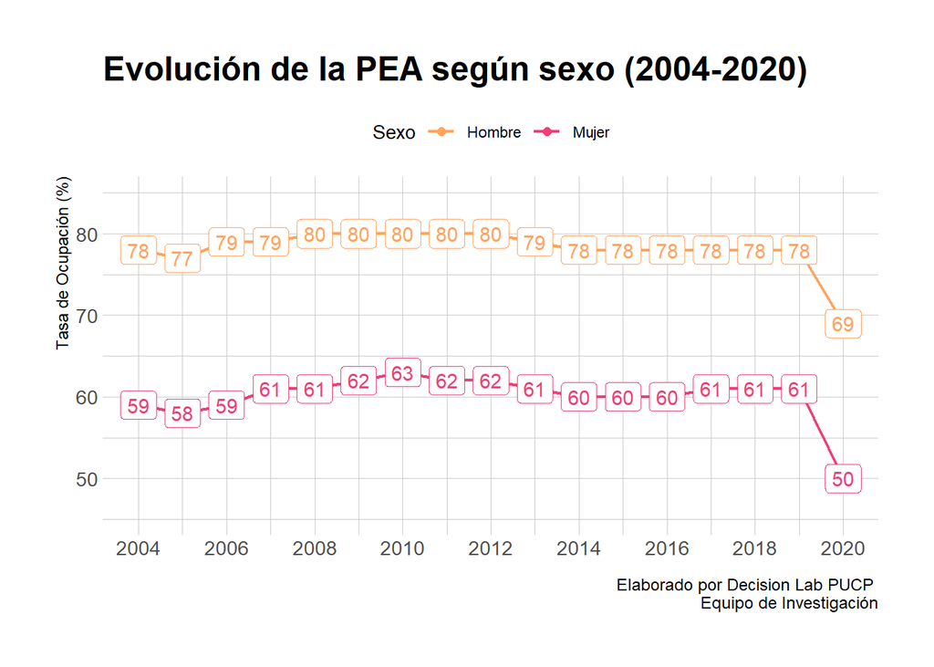

### **Evolución de tasa de desempleo abierto según sexo**

> Se observan valores similares entre hombres y mujeres. Asimismo, la variación en el último año es equivalente en ambos (alrededor de 3pp).

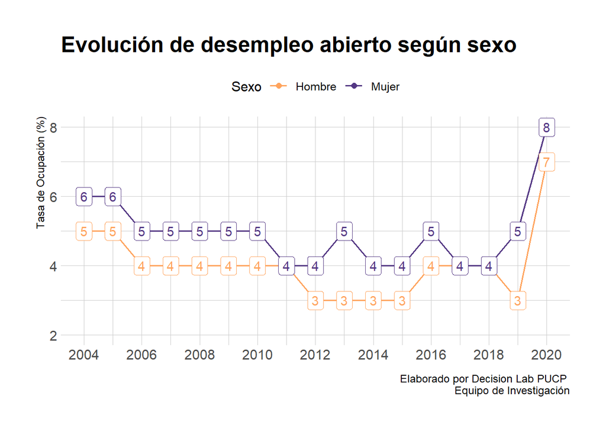

### **Evolución de tasa de ocupación según ámbito geográfico**

> Se observa menores índices de ocupación (menores a 70 pp) en personas de zonas rurales. Estos bajos índices disminuyen aún más en el último año (caída alredor de 13pp).

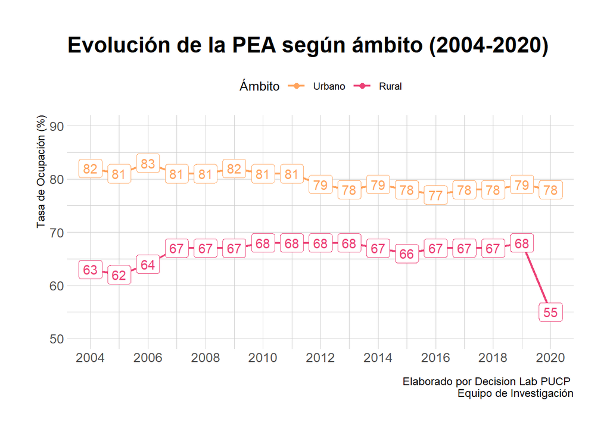

### **Evolución de tasa de ocupación según nivel educativo**

> Se observa menores índices de ocupación (menores a 60 pp) en personas con educación universitaria, seguidos por personas sin nivel educativo. Estos bajos índices disminuyen aún más en el último año (caída alredor de 11pp).

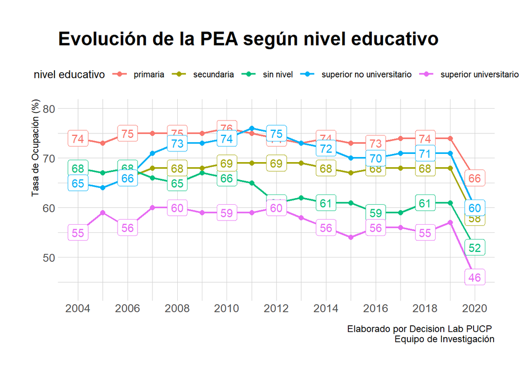

### **Evolución de tasa de ocupación según grupo etario**

> Se observa menores índices de ocupación (menores a 50 pp) en adultos mayores, seguidos por jóvenes. Estos bajos índices disminuyen aún más en el último año (caída alredor de 6pp).

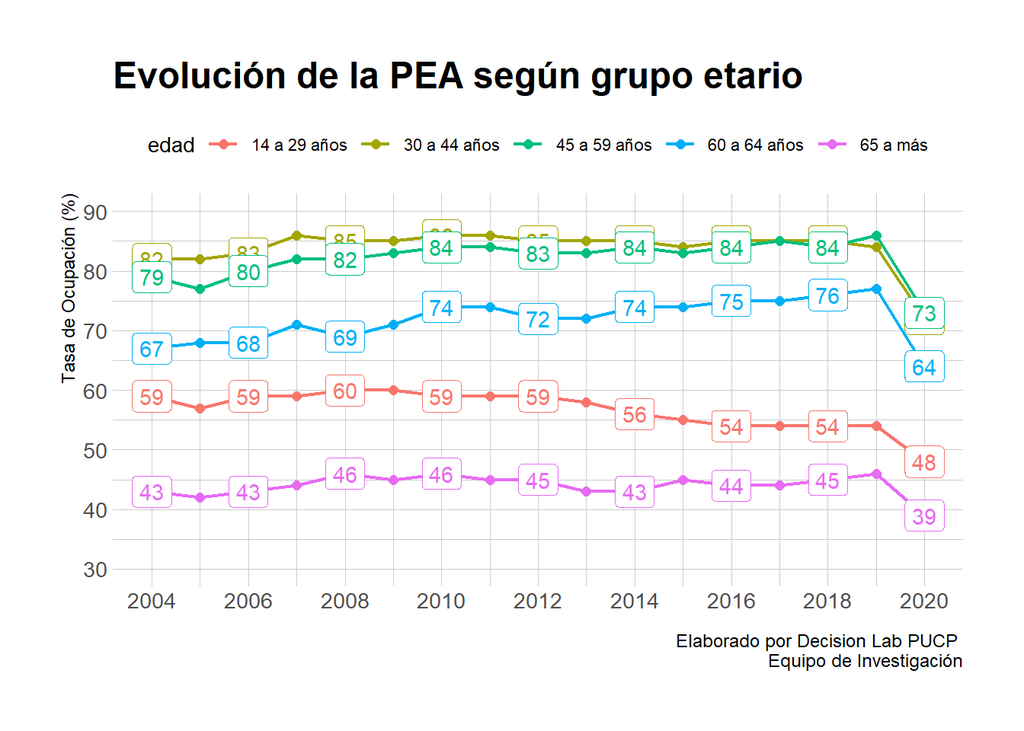

## 3.2 Formalidad e informalidad

### **Evolución de la tasa de empleo informal según sexo**

> Se observa una brecha entre hombres y mujeres (alrededor de 7 pp). En el último año, se observa que esta se reduce a 3pp a raíz de un aumento de la informalidad en hombres.

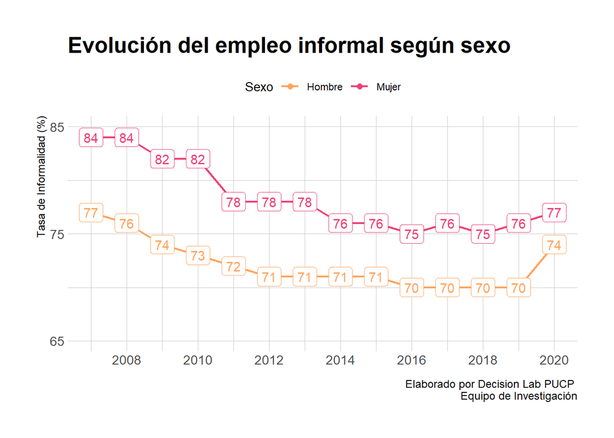

### **Evolución de la tasa de empleo informal según ámbito geográfico**

> Se observa una amplia brecha entre las personas de origen rural y urbano (cercanos a 30 pp). Sin embargo, no se encuentra una variación considerable de la brecha por la pandemia (29 vs 28 pp).

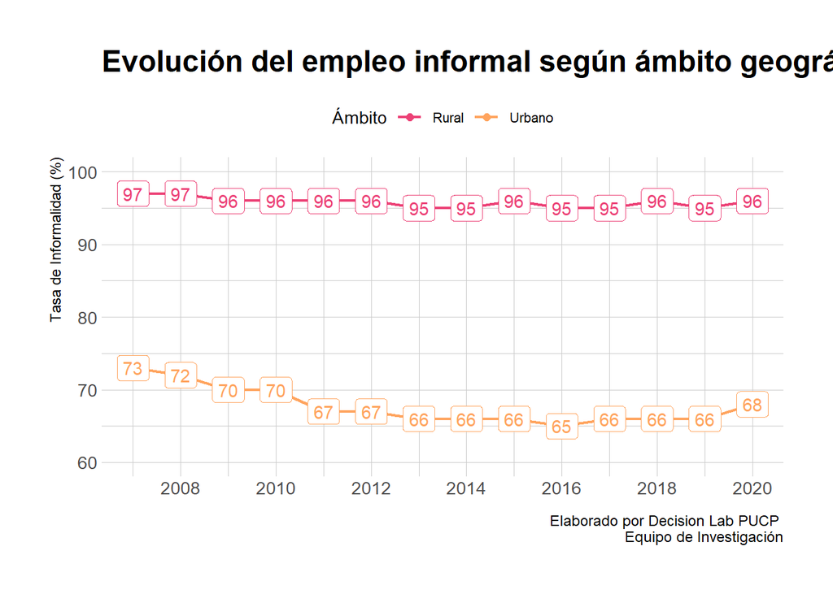

### **Evolución de la tasa de empleo informal según nivel educativo**

> Se observa mayores índices de empleo informal (mayores a 90 pp) en personas sin nivel educativo o solo con primaria completa. Sin embargo, el impacto por la pandemia es mayor en personas con educación universitaria (7 pp)

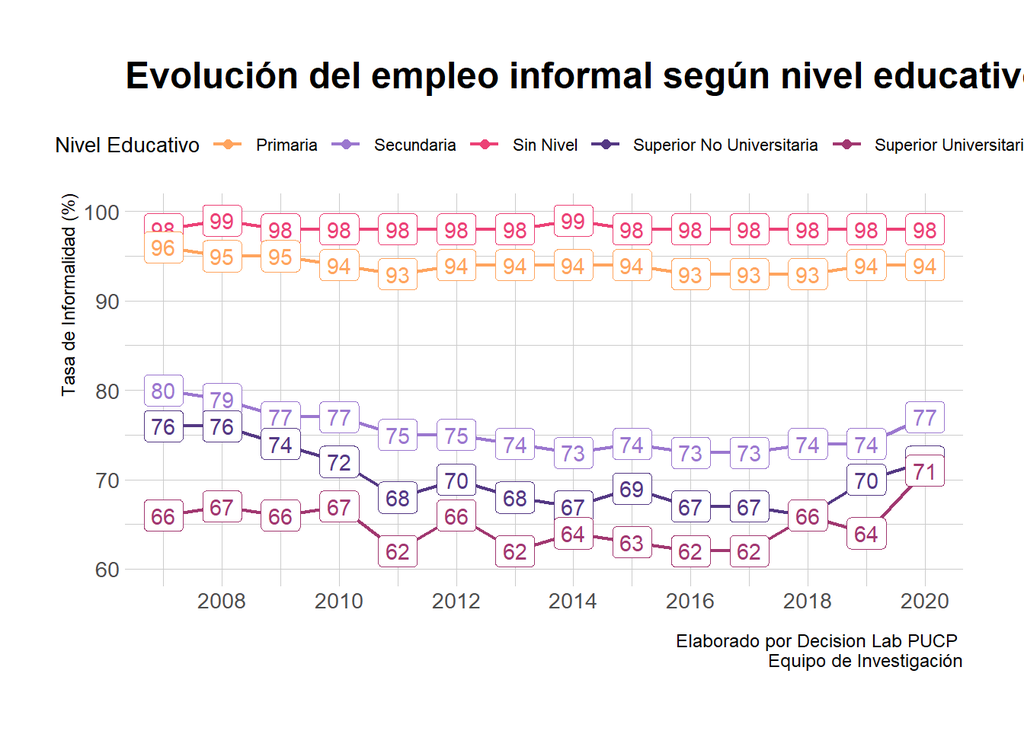

### **Evolución de la tasa de empleo informal según grupo etario**

> Se observa mayores índices de empleo informal (cercanos a 90 pp) en los adultos mayores, seguidos por los jóvenes.

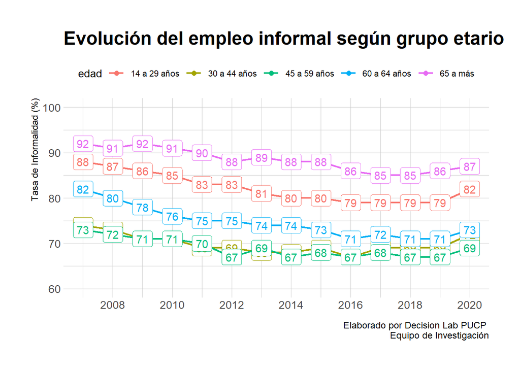